# Tarea 6

Bajo esta representación, al contar con $28$ variables, los resultados no se aprecian lo suficiente; entonces, se decide realizar un análisis gráfico.

Se realiza el mapa de factores para $m=2$, donde se observa que las variables (preguntas) de la misma clase se agrupan; no obstante, existen algunas carácteristicas que se mezclan; i.e., en la base se tienen 5 tipos de preguntas; sobre la amabilidad (A), conciencia (C), extraversión (E), neurotismo (N) y franquza (O).

En el mapa factorial se puede ver cosas interesantes, en la representción de los dos primeros factores, se observan grupos marcados, las variables que hablan sobre la amabilidad, lo extrovertido y lo conciente que es un individuo, en el lado izquierdo, contribuyendo más al primer factor; y las variables que hacen referencia al neurotismo contribuyen más al segundo factor.

Dentro de las que contribuyen más al primer factor, se encuentra un contraste, el cual hace referencia a lo extrovertido que son los individuos; i.e., las variables E1 y E2 respecto a la E3,E4 Y E5; lo cual tiene sentido, ya que E1, indica que si la persona habla mucho; E2, que si encuentra dificultad en hablar con otros; el resto de las variables en el grupo de extroversión indican cosas como: sabe cautivar a la gente o hace amigos de forma sencilla.

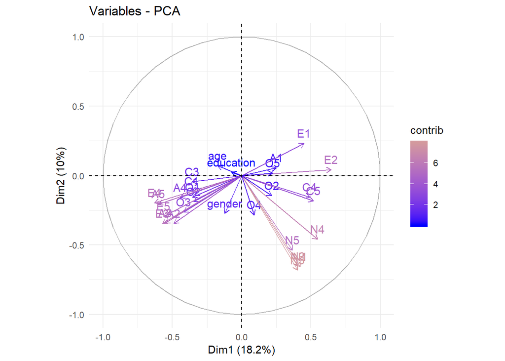

```r
# Mapa factorial
fviz_pca_var(ven.pca, col.var="contrib")+
  scale_color_gradient2(low="blue", mid="yellow",high="red", midpoint=14)+
  theme_minimal()
```

Ahora, se realiza el análisis por factor; i.e, las contribuciones de las variables a las componentes principales. Aquí se espera que cada variable este sobre la linea roja, indicando el aporte en las misma cuantia para cada componente.

En el gráfico de abajo podemos observar lo ya mencionado sobre que variables contribuyen más al primer factor; aquellas preguntas que hacen referencia a la amabilidad, extroversión y concienia.

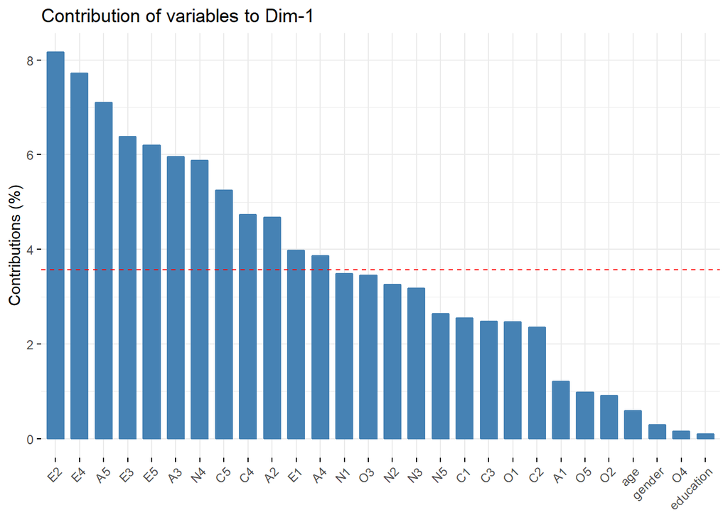

```r
# Primera componente
fviz_contrib(ven.pca, choice = "var", axes = 1)
```

Ahora con la segunda componente; se detecta que la mayor contribución a este factor son las variables que hacen mención al neurotismo.

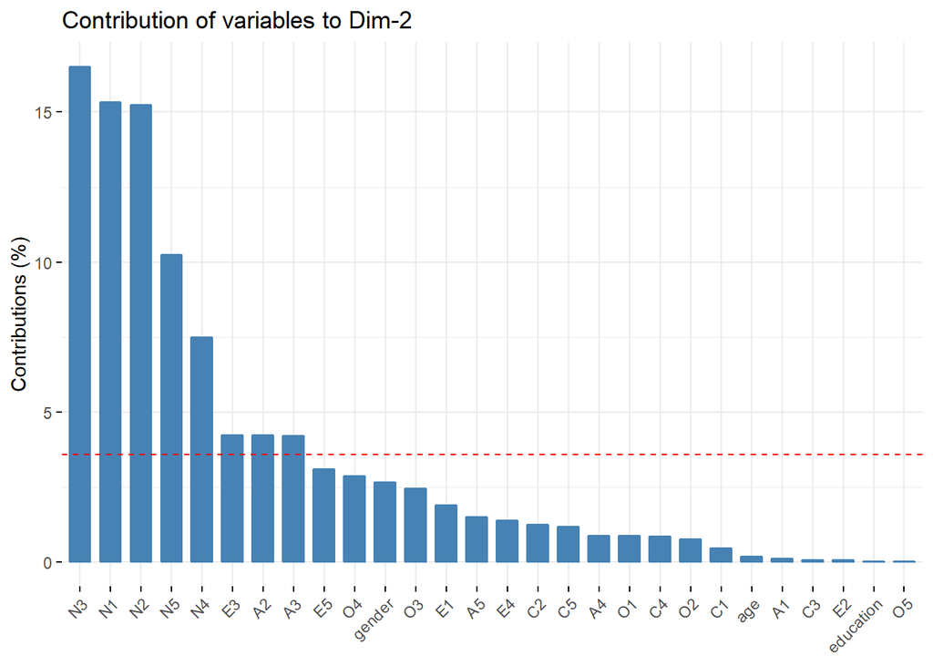

```r
# Segunda componente
fviz_contrib(ven.pca, choice = "var", axes = 2)
```

**c) Identifica las preguntas que tienen una preponderancia de acuerdo extremo y / o en desacuerdo las respuestas. Del mismo modo, identifica casos atípicos tales como personas que parecen responder de manera extrema. Es decir, las personas que tienden a estar totalmente de acuerdo o en desacuerdo con la mayoría de las preguntas.**

En el inciso c) se indica que se encuentren las respuestas que tienen una preponderancia de acuerdo extremo o desacuerdo, y bajo la representación del gráfico de factores se epueden encontrar algunas, como las que se presentan a continuación:

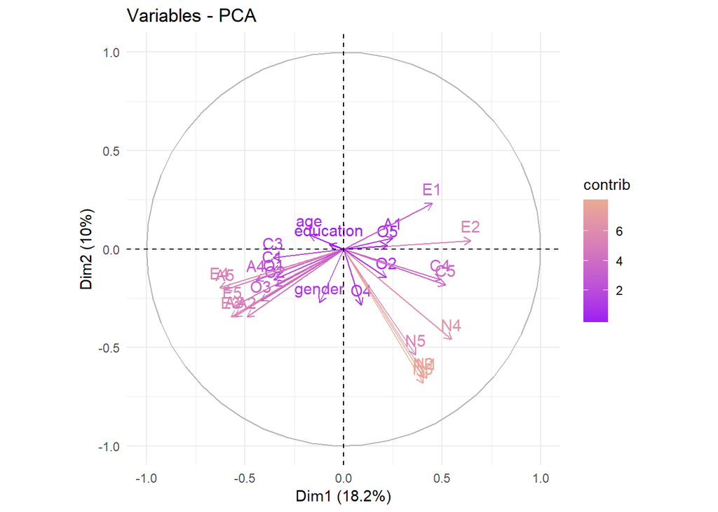

```r
# Mapa factorial
fviz_pca_var(ven.pca, col.var="contrib")+
  scale_color_gradient2(low="purple", mid="yellow",high="red", midpoint=14)+
  theme_minimal()
```

Entre estas se tienen:

E1: No habla mucho E2: Encunentra difícil hablar con los demas

Todas las de la categoria de neurotismo (N1,N2,N3,N4)

Se identifican casos atípicos tales como personas que parecen responder de manera extrema; es decir, las personas que tienden a estar totalmente de acuerdo o en desacuerdo con la mayoría de las preguntas. Se gráfica el mapa de factores por inidviduo para localizar las respuestas extremas; bajo esta representación se encuentran a individuos con respuestas extremas, cabe a clarar que más adelante se tiene en que respuestas los individuos contestan de forma extrema.

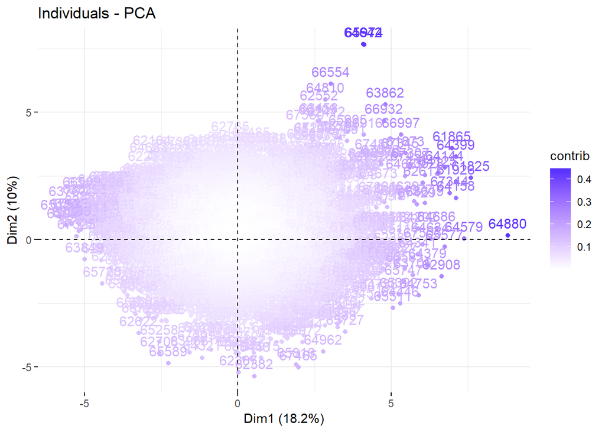

```r
# Calidad de los individuos en el mapa factorial
fviz_pca_ind(ven.pca, col.ind="contrib") +
  scale_color_gradient2(low="white", mid="blue",
                        high="red", midpoint=0.50)
```

Si se colorea por su contribución no se aprecia muy bien; entonces, se colorea por la calidad de la representación.

Entre los individuos con respuestas extremas se encuentran los dos en la esquina superior derecha, cuya etiqueta se traslapan; aismismo, el individuo $66554$; por otro lado, en ese cuadrante pero cerca al eje de las abscisas, el individuo $64880$.

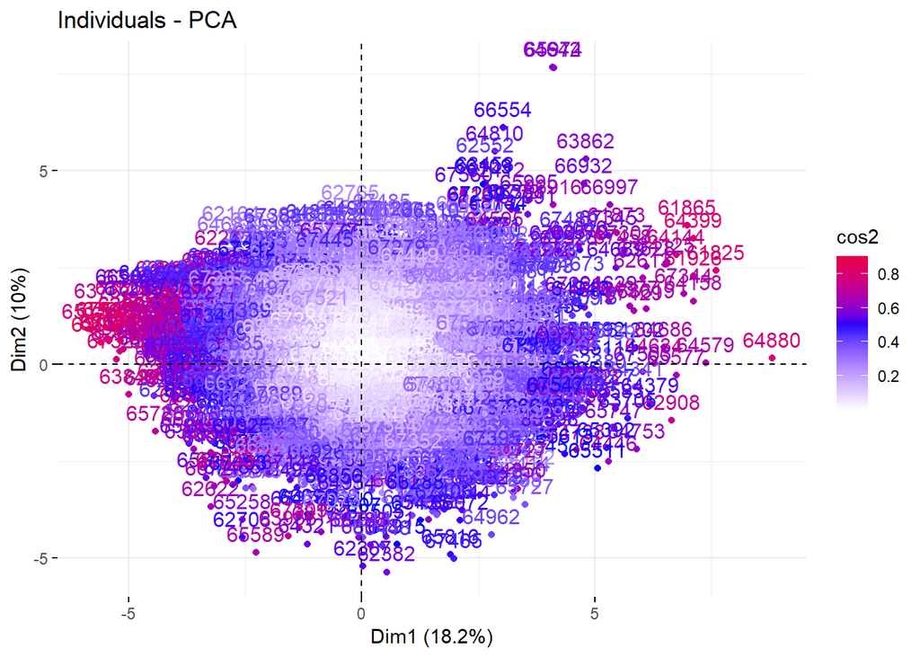

```r
# Calidad de los individuos en el mapa factorial
fviz_pca_ind(ven.pca, col.ind="cos2") +
  scale_color_gradient2(low="white", mid="blue",
                        high="red", midpoint=0.50)
```

```r
# NOTA: cos2 = la calidad de los individuos en el mapa de calor
```

Si se desea observar lo anterior para cada factor, dado la cantidad de individuos que se tienen, será difícil localizarlos; para sostener lo dicho, a continuación, se presentan las contribuciones de los individuos en cada factor.

Primera componente:

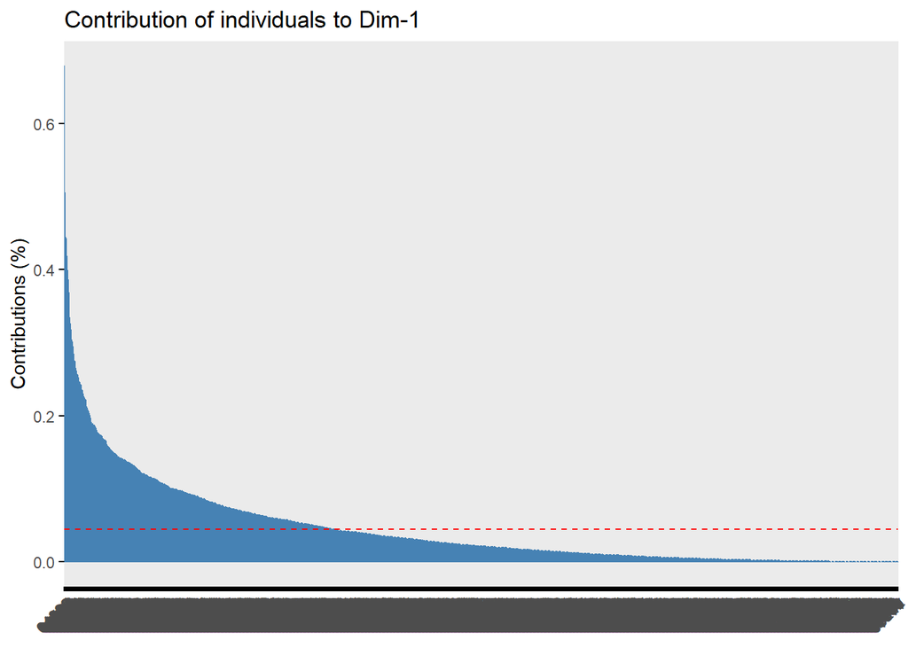

```r
# Primera componente
fviz_contrib(ven.pca, choice = "ind", axes = 1)
```

Segunda componente:

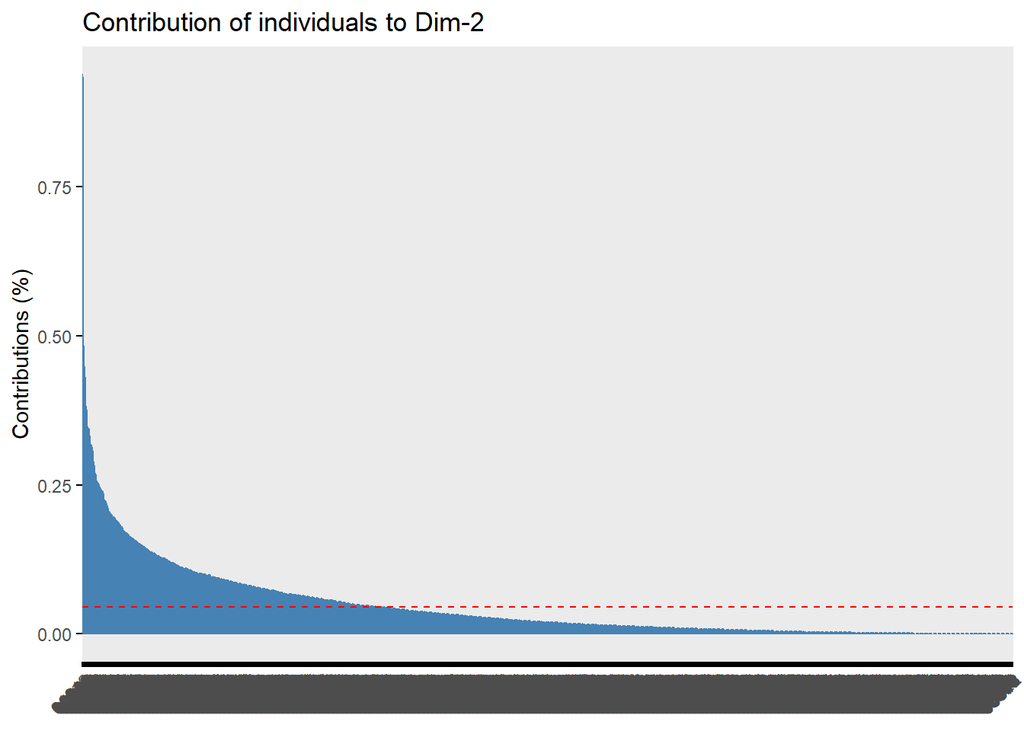

```r
# Primera componente
fviz_contrib(ven.pca, choice = "ind", axes = 2)
```

Se localizan los individuos con respuestas extremas y cuales son esas respuestas.

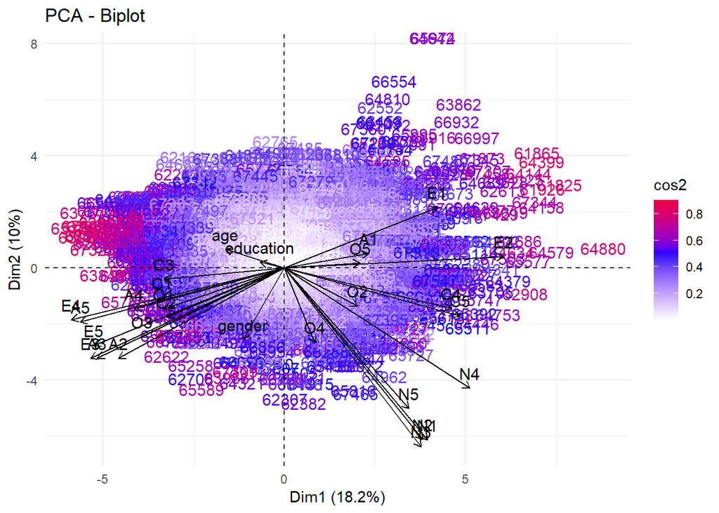

```r
# Biplot de individuos y variables
fviz_pca_biplot(ven.pca, geom = "text", col.ind="cos2", col.var = "black") +
  scale_color_gradient2(low="white", mid="blue",
                        high="red", midpoint=0.50) +
  theme_minimal()
```

De forma de ejemplo, se realiza un filtrado en el individuo $66554$, el cual tiene como pregunta extrema la E1, indicando que no habla mucho; la A1, que es indiferente a los demas; y el E2, que le cuesta hablar con otras personas. Este individuo cuenta con un nivel de educación universitaria (cursandola) y con edad de 23 años, lo cual carácteriza bien su respuestas. Esta persona cae dentro del contraste del primer factor, que representa el contrario de los individuos sociales.

```r
library("tidyverse")
obs <- rownames_to_column(datos, var="label")
obs %>% filter(label==66554)
```

```
##   label A1 A2 A3 A4 A5 C1 C2 C3 C4 C5 E1 E2 E3 E4 E5 N1 N2 N3 N4 N5 O1 O2
## 1 66554  6  1  1  6  1  6  5  6  1  1  6  6  1  1  1  1  1  1  1  1  6  1
##   O3 O4 O5 gender education age
## 1  1  6  1      1         3  23
```

Otro individuo con respuestas extrema es el 64880, que también cae dentro de los contrastes del primer factor, al responder lo contrario de ser un individuo social y amable.

Por último, lo aterior se realizó estimando los factores con PCA; a continuación solo se estiman los factores con maxima verosimilitud y se contrastan los residuales respecto a los de la estimación por PCA.

Nota: no se realiza de nuevo el análisis, solo se contrastan residuales para ver que método aproxima mejor la matriz de correlación de los datos.

Por ML, dos factores:

```r
var_vend.fa2<- factanal(covmat=R,factors=2)
CARGAS2<-var_vend.fa2$loadings # Cargas factoriales
LL <- CARGAS2%*%t(CARGAS2)
VAR_ESP2<-var_vend.fa2$uniquenesses # Singularidades
residuales <- R - LL - diag(VAR_ESP2)
residuales %>%  norm
```

```
## [1] 2.322079
```

la norma de los residuales es $2.322079$, utilizando MV

```r
residuales2 <- R - RESULTADO$LL - RESULTADO$Phi
residuales %>%  norm
```

```
## [1] 2.322079
```

## EJERCICIO 6

**6. El conjunto de datos Harmon23.cor en el paquete “datasets” es una matriz de correlación de ocho mediciones físicas realizadas en 305 niñas entre las edades de 7 y 17 años.**

Antes de realizar el análisis de factores se determina si existe correlación entre grupps de variables.

Se observa el gráfico de correlación y se ve que a lo menos existen variables con alto nivel de correlación; ejemplo, altura con la variabale arm.spam yforerman, entre otros.

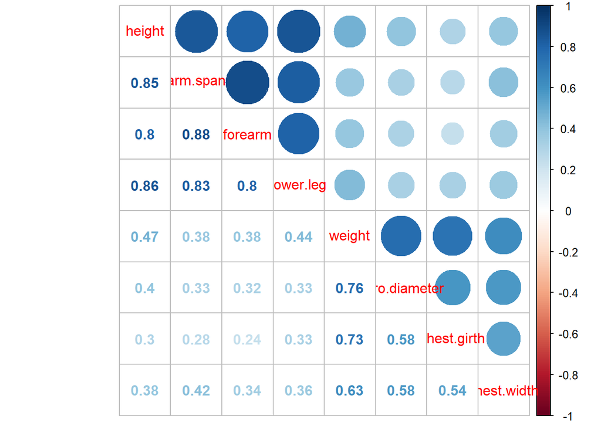

```r
library("corrplot")
R <- datasets::Harman23.cor
R <- R$cov
corrplot.mixed(R)
```

Se realiza la prueba de Bartlett para probar la hipótesis nula de que las variables no están correlacionadas.

Se encuetra evidencia suficiente para rechazar la hipótesis nula; por lo tanto, si existe correlación entre las variables.

```r
n <- 305
cortest.bartlett(R,n)
```

```
## $chisq
## [1] 2085.74
##
## $p.value
## [1] 0
##
## $df
## [1] 28
```

Ahora se utiliza la prueba KMO para ver que tan bueno es realizar análisis de factores en los datos.

El valor MSA es de $.85$, por lo tanto, bajo el críterio de clasificación es bueno utilizar análisis de factores sobre este conjunto de datos.

```r
# Indice KMO
# - KMO > 0.90    Muy bueno
# - 0.80<KMO<0.90 Bueno
# - 0.70<KMO<0.80 Aceptable
# - 0.60<KMO<0.70 Regular
# - 0.50<KMO<0.60 Malo
# - KMO < 0.50    Inaceptable
KMO(R)
```

```
## Kaiser-Meyer-Olkin factor adequacy
## Call: KMO(r = R)
## Overall MSA =  0.85
## MSA for each item =
##         height       arm.span        forearm      lower.leg         weight
##           0.86           0.82           0.86           0.89           0.78
## bitro.diameter    chest.girth    chest.width
##           0.85           0.82           0.90
```

**a) Realiza un análisis factorial de estos datos.**

**b) Varía el número de factores para encontrar un ajuste adecuado del modelo e interprete las cargas factoriales resultantes.**

Para evaluar que número de factores utilizar, se realiza la prueba ji cuadradra. Antes de aplicar la prueba, se observa si es posible realizarla:

$$m<\frac{1}{2}(2*p+1-\sqrt(8*p+1)$$

con 2 factores; si se puede.

```r
m <- 2
p <- dim(R)[2]
m < .5*(2*p + 1 - sqrt(8*p + 1))
```

```
## [1] TRUE
```

con 3 factores, también.

```r
m <- 3
p <- dim(R)[2]
m < .5*(2*p + 1 - sqrt(8*p + 1))
```

```
## [1] TRUE
```

con 5 factores, no se puede.

```r
m <- 5
p <- dim(R)[2]
m < .5*(2*p + 1 - sqrt(8*p + 1))
```

```
## [1] FALSE
```

Se realiza la prueba con factores de 2 al 4, ya que con uno factor dan problemas conocidos como casos Heywood, y con 5 en adelate ya no es valido hacer la prueba ji cuadrada.

```r
testFactores <- function(m, LL, phi, Sn, alpha, n, p)
{
  EstPrueba <- (n-1-((2*p+4*m+5)/6))*log(det(LL+phi)/det(Sn))
  gradosLibertad <- (((p-m)^2)-p-m)/2
  ValCrit <- qchisq(alpha,gradosLibertad, lower.tail = F)
  Resultado <- EstPrueba > ValCrit
  return(list(estadistico = EstPrueba, gl = gradosLibertad, critico = ValCrit, Rehaza = Resultado))
}
```

Se estiman factores con MV y se realiza la prueba para detérminar el número de factores, con $m=2$

```r
library("psych")
factors <- factanal(covmat = R, factors=2)
LL <- factors$loadings%*%t(factors$loadings)
phi <- factors$uniquenesses %>% diag
testFactores(2, LL, phi, R, .05, 305, dim(R)[2])
```

```
## $estadistico
## [1] 75.73361
##
## $gl
## [1] 13
##
## $critico
## [1] 22.36203
##
## $Rehaza
## [1] TRUE
```

Con dos factores si se tiene evidencia para rechazar la hipótesis nula de que el modelo con $m=2$ factore se ajusta bien a los datos.

Con $3$ factores, también se rechaza la hipótesis nula.

```r
factors <- factanal(covmat = R, factors=3)
LL <- factors$loadings%*%t(factors$loadings)
phi <- factors$uniquenesses %>% diag
testFactores(3, LL, phi, R, .05, 305, dim(R)[2])
```

```
## $estadistico
## [1] 23.02947
##
## $gl
## [1] 7
##
## $critico
## [1] 14.06714
##
## $Rehaza
## [1] TRUE
```

Es con $4$ factores cuando no se rechaza la hipótesis nula, y con 4 factores se ajustan bien a los datos.

```r
factors <- factanal(covmat = R, factors=4)
LL <- factors$loadings%*%t(factors$loadings)
phi <- factors$uniquenesses %>% diag
testFactores(4, LL, phi, R, .05, 305, dim(R)[2])
```

```
## $estadistico
## [1] 4.961171
##
## $gl
## [1] 2
##
## $critico
## [1] 5.991465
##
## $Rehaza
## [1] FALSE
```

Se utilizan 4 factores para realizar el análisis.

```r
factores <- factanal(covmat = R,factors=4)
cargas <- factores$loadings # Cargas factoriales
varEspecifica <- factores$uniquenesses # Singularidades
LL <- cargas%*%t(cargas)
cumunalidades <- LL %>% diag
```

Se calcula el residual de la aproximación a la matriz de correlación.

```r
Rest <- LL + diag(varEspecifica)
round(R-Rest,digits=3)
```

```
##                height arm.span forearm lower.leg weight bitro.diameter
## height          0.000        0  -0.007     0.001  0.001          0.004
## arm.span        0.000        0   0.000     0.000  0.000          0.000
## forearm        -0.007        0   0.000     0.002  0.007          0.000
## lower.leg       0.001        0   0.002     0.000 -0.002         -0.001
## weight          0.001        0   0.007    -0.002  0.000         -0.002
## bitro.diameter  0.004        0   0.000    -0.001 -0.002          0.000
## chest.girth     0.000        0  -0.002     0.000  0.001          0.001
## chest.width    -0.011        0  -0.020     0.012  0.002          0.006
##                chest.girth chest.width
## height               0.000      -0.011
## arm.span             0.000       0.000
## forearm             -0.002      -0.020
## lower.leg            0.000       0.012
## weight               0.001       0.002
## bitro.diameter       0.001       0.006
## chest.girth          0.000      -0.006
## chest.width         -0.006       0.000
```

Se observa que la matriz de residuale tiene elementos casis cero y cero.

Se observan las cargas de los factores (coeficientes)

```r
factors$loadings
```

```
##
## Loadings:
##                Factor1 Factor2 Factor3 Factor4
## height          0.879   0.277          -0.115
## arm.span        0.937   0.194           0.277
## forearm         0.875   0.191
## lower.leg       0.887   0.209   0.135  -0.188
## weight          0.246   0.882   0.111  -0.109
## bitro.diameter  0.187   0.822
## chest.girth     0.117   0.729   0.526
## chest.width     0.263   0.644           0.141
##
##                Factor1 Factor2 Factor3 Factor4
## SS loadings      3.382   2.595   0.323   0.165
## Proportion Var   0.423   0.324   0.040   0.021
## Cumulative Var   0.423   0.747   0.787   0.808
```

Se observa que las variables como altura, el alcance del brazo (ar.spam), el antebrazo y la parte inferior de la pierna, son las variables que más contribuyen al primer factor; el segundo factor, las variables que más le contribuyen son: el peso y bitro.diameter; el tercer factor le contribuye más la variable que mide la circunferencia del pecho (chest.girth), y en el cuarto se puede decir que se centra en el ancho del pecho, que a la vez se relaciona con el alcance de los brazos.

Nombrando los factores se tiene:

Primer factor es el de extremidades.

Segundo factor el de masa corporar,

Tercer factor circunferencia del pecho

Cuarto factor el de ancho de pecho

No se pueden utilizar los factor scores dado que no tenemos los datos originales, entonces se tiene que utilizar la estimción con PCA.

Para estimar los factores con PCA se utilizan criterios de PCA para seleccionar los factores.

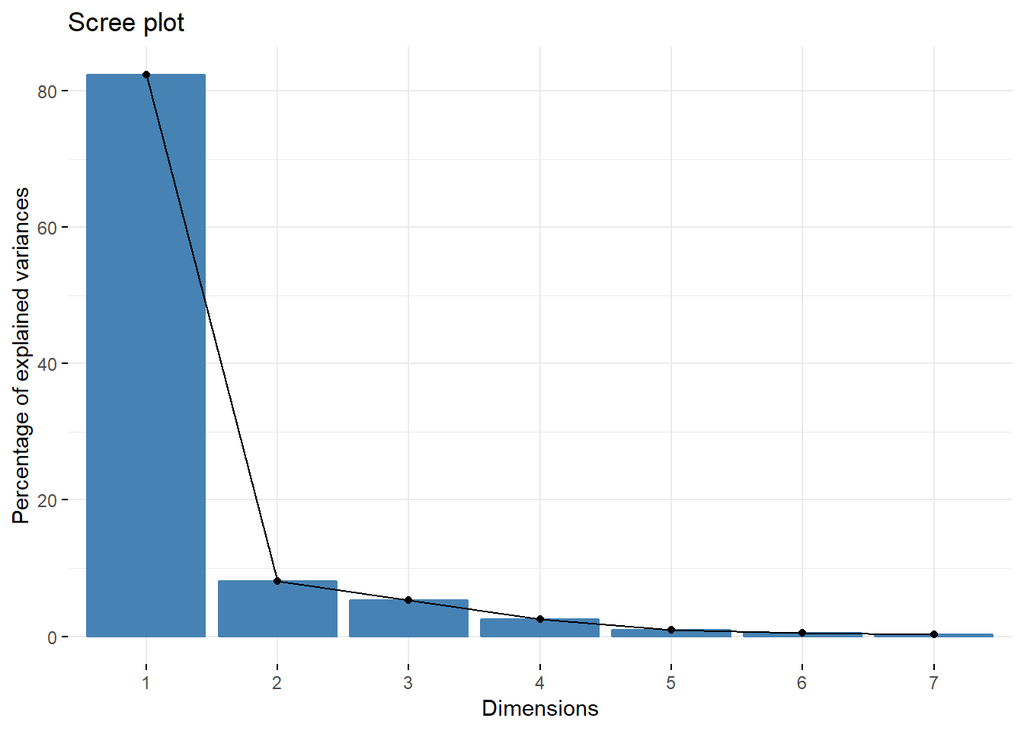

```r
library("factoextra")
library("ade4")
ven.pca <- dudi.pca(R, scannf = FALSE, nf = 2,scale = T)
eig.val <- get_eigenvalue(ven.pca)
fviz_screeplot(ven.pca)
```

Con el screeplot se observa que a lo mucho dos factores son los adecuados.

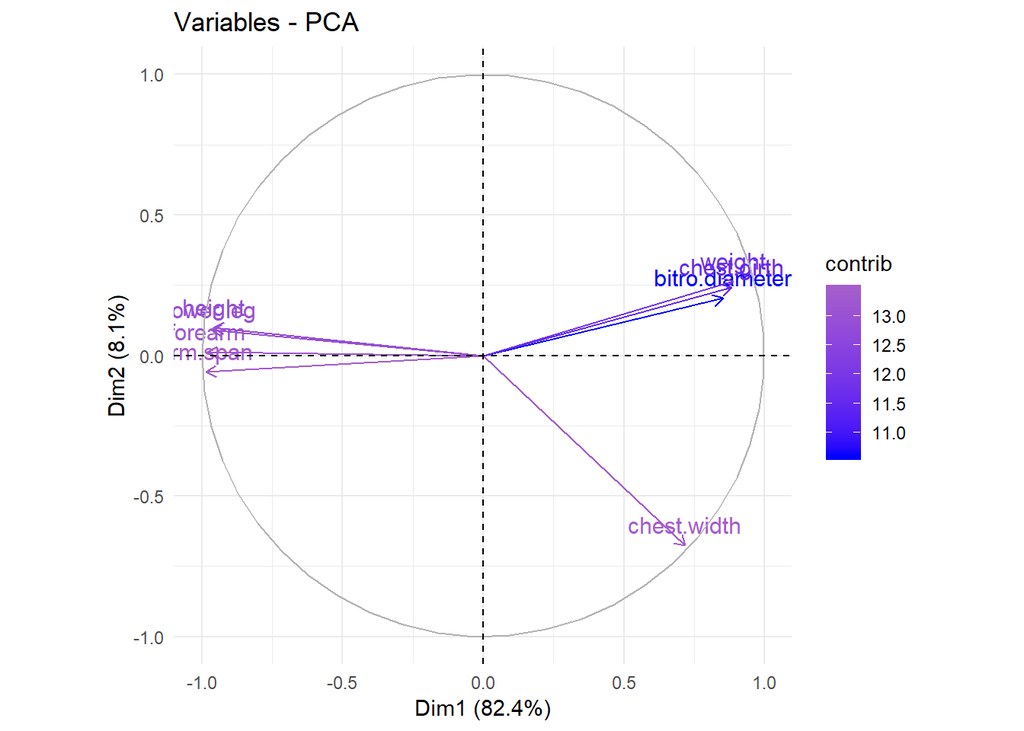

```r
# Mapa factorial
fviz_pca_var(ven.pca, col.var="contrib")+
  scale_color_gradient2(low="blue", mid="yellow",high="red", midpoint=20)+
  theme_minimal()
```

Con la representación del gráfico anterior se observar que el primer factor contiene el $82\%$ de la varianza total explicada; con los dos factores se tiene que las variables como la altura, alcance del brazo, antebrazo, y el largo de la parte baja del pie se agrupan y son las variables que más aportan al primer factor; también en este factor se observa un contraste, que tiene relación con el medidas del pecho y altura, los cuales contribuyen en gran medida al primer factor; y el segundo factor la variable que más lo explica es la anchura del pecho (chest width).

Ahora, se realiza el análisis por factor; i.e, las contribuciones de las variables a las componentes principales. Aquí se espera que cada variable este sobre la linea roja, indicando que aportan en las misma cuantia en cada componente.

Se ve que la distribución en la contribución tiende a ser homogenea para el primer factor; sin embargo, esto cambia con el segundo factor.

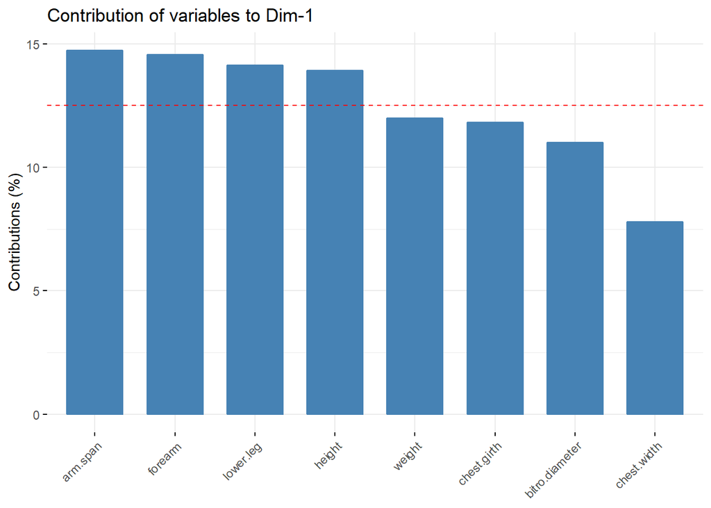

```r
# Primera componente
fviz_contrib(ven.pca, choice = "var", axes = 1)
```

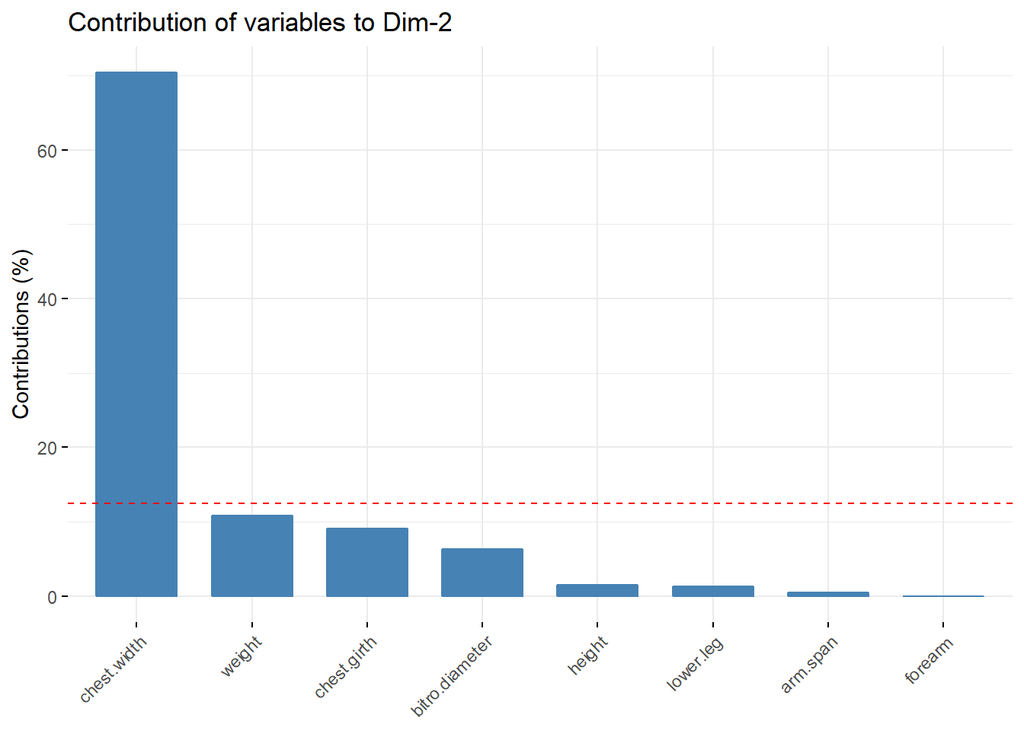

```r
# Segunda componente
fviz_contrib(ven.pca, choice = "var", axes = 2)
```

En conclusión, nos quedamos con la interpretación de la estimación de MV, ya que con más factores se logró clasificar a los siguientes grupos.

Primer factor es el de extremidades.

Segundo factor el de masa corporar,

Tercer factor circunferencia del pecho

Cuarto factor el de ancho de pecho

Con dos factores y utilizando PCA, para estimar a los factores, se encuentra lo siguiente:

Primer factor es el individuos altos.

Segundo factor el de individuos bajos y robustos.